# 산업단지조성, 실제로 건강에 문제를 일으킬까?

김효진

## 프로젝트 시행 배경

산업단지(대체로 거부하는)가 들어서면 그 주변 주민들은 항상 반대하는 **‘님비현상(NIMBY, Not In My Back Yard)’**은 우리주변에서 자주 찾아볼 수 있다. 산업단지 즉, 공장을 거부하는 이유 중 하나는 **‘건강에 좋지 않다.’**라는 의견이 있다. 그렇다면 서울시 내에 실제로 공장이 많은 지역의 병원 이용자 수는 몇명인지, 그리고 산업 중 제조업으로 한정하여 파악하기로 하였다. 또한 장애인 현황과, 응급실 이용자현황, 자동차 등록 현황, 대기오염현황, 결핵관리 현황 등 다양한 데이터를 활용하여 더 디테일한 분석을 시행하려고 한다.

[figure not shown]

## 프로젝트에 사용 할 데이터

### 1. 서울시 제조업현황 (산업중분류별) 통계_2016

- 작성목적 : 광업 및 제조업부문의 사업체 및 종사자 현황과 생산ㆍ출하ㆍ재고액의 추이를 파악하여, 산업활동과 관련된 각종 정책의 수립 및 평가, 기업의 경영계획 수립 및 학계, 연구소 등의 학술연구를 위한 기초자료를 제공하는 것을 목적으로 함
- 공표주기 : 정기(매년, 12월 기준)
- 내용 - 서울시 제조업의 산업중분류별(식료품, 음료, 섬유제품 등) 사업체수, 종사자수, 연간급여액, 생산ㆍ출하ㆍ재고액, 주요생산비, 부가가치, 유형자산연말잔액 등이 표시되어 있음  
  **따라서 내용과 작성목적이 위의 분석하려는 의도와 부합하여 선택**하였다.

```r
library(readxl)
manu_2016 <- read_excel("manu_2016.xlsx")
head(manu_2016, 5)
```

```
## # A tibble: 5 x 52
##   기간  자치구 합계  합계__1 식료품 식료품__1 음료  음료__1
##   <chr> <chr>  <chr> <chr>   <chr>  <chr>     <chr> <chr>
## 1 기간  자치구 사업체수~ 종사자수~ 사업체수~ 종사자수  사업체수~ 종사자수~
## 2 2016  합계   4292  112136  116    3361      9     291
## 3 2016  종로구 108   2251    -      -         -     -
## 4 2016  중구   257   5683    -      -         -     -
## 5 2016  용산구 29    1026    2      X         -     -
## # ... with 44 more variables: `섬유제품 ; 의복제외` <chr>, `섬유제품 ;
## #   의복제외__1` <chr>, `의복 의복액세서리 및 모피제품` <chr>, `의복
## #   의복액세서리 및 모피제품__1` <chr>, `가죽 가방 및 신발` <chr>, `가죽
## #   가방 및 신발__1` <chr>, `목재 및 나무제품 ; 가구제외` <chr>, `목재 및
## #   나무제품 ; 가구제외__1` <chr>, `펄프종이 및 종이제품` <chr>, `펄프종이
## #   및 종이제품__1` <chr>, `인쇄 및 기록매체 복제업` <chr>, `인쇄 및
## #   기록매체 복제업__1` <chr>, `코크스 연탄 및 석유정제품 제조업` <chr>,
## #   `코크스 연탄 및 석유정제품 제조업__1` <chr>, `화학물질 및 화학제품 ;
## #   의약품 제외` <chr>, `화학물질 및 화학제품 ; 의약품 제외__1` <chr>,
## #   `의료용물질 및 의약품` <chr>, `의료용물질 및 의약품__1` <chr>, `고무
## #   및 플라스틱제품` <chr>, `고무 및 플라스틱제품__1` <chr>, `비금속
## #   광물제품` <chr>, `비금속 광물제품__1` <chr>, `제1차 금속산업` <chr>,
## #   `제1차 금속산업__1` <chr>, `금속가공제품 기계및가구 제외` <chr>,
## #   `금속가공제품 기계및가구 제외__1` <chr>, `전자부품 컴퓨터 영상 음향 및
## #   통신장비` <chr>, `전자부품 컴퓨터 영상 음향 및 통신장비__1` <chr>,
## #   `의료정밀광학기기 및 시계` <chr>, `의료정밀광학기기 및 시계__1` <chr>,
## #   전기장비 <chr>, 전기장비__1 <chr>, `기타 기계 및 장비` <chr>, `기타
## #   기계 및 장비__1` <chr>, `자동차 및 트레일러` <chr>, `자동차 및
## #   트레일러__1` <chr>, 기타운송장비 <chr>, 기타운송장비__1 <chr>,
## #   가구 <chr>, 가구__1 <chr>, 기타제품 <chr>, 기타제품__1 <chr>,
## #   `산업용기계 및 장비수리업` <chr>, `산업용기계 및 장비수리업__1` <chr>
```

- 출처 : 서울열린데이터광장 서울시 제조업현황 (산업중분류별) 통계 [링크](https://data.seoul.go.kr/dataList/datasetView.do?infId=107&srvType=S&serviceKind=2&currentPageNo=1&searchValue=&searchKey=null)

### 2. 서울시 장애인 현황 (장애유형별) 통계_2016

- 작성목적 : 장애인의 전반적인 현황을 파악하여 장애인 관련 정책 수립을 위한 기초자료를 제공하는 것을 목적으로 함
- 공표주기 : 정기(매년, 12월 기준)
- 내용 - 서울시 등록장애인의 장애유형별 현황 파악  
  **따라서 내용과 작성목적이 위의 분석하려는 의도와 부합하여 선택**하였다.

```r
disable_2016 <- read_excel("disable_2016.xlsx")
head(disable_2016, 5)
```

```
## # A tibble: 5 x 50
##   기간  자치구 합계  합계__1 합계__2 장애유형 장애유형__1 장애유형__2
##   <chr> <chr>  <chr> <chr>   <chr>   <chr>    <chr>       <chr>
## 1 기간  자치구 합계  합계    합계    지체     지체        지체
## 2 기간  자치구 계    남자    여자    계       남자        여자
## 3 2016  서울시 3910~ 227271  163756  189777   107226      82551
## 4 2016  종로구 6072  3492    2580    2935     1564        1371
## 5 2016  중구   5719  3294    2425    2829     1532        1297
## # ... with 42 more variables: 장애유형__3 <chr>, 장애유형__4 <chr>,
## #   장애유형__5 <chr>, 장애유형__6 <chr>, 장애유형__7 <chr>,
## #   장애유형__8 <chr>, 장애유형__9 <chr>, 장애유형__10 <chr>,
## #   장애유형__11 <chr>, 장애유형__12 <chr>, 장애유형__13 <chr>,
## #   장애유형__14 <chr>, 장애유형__15 <chr>, 장애유형__16 <chr>,
## #   장애유형__17 <chr>, 장애유형__18 <chr>, 장애유형__19 <chr>,
## #   장애유형__20 <chr>, 장애유형__21 <chr>, 장애유형__22 <chr>,
## #   장애유형__23 <chr>, 장애유형__24 <chr>, 장애유형__25 <chr>,
## #   장애유형__26 <chr>, 장애유형__27 <chr>, 장애유형__28 <chr>,
## #   장애유형__29 <chr>, 장애유형__30 <chr>, 장애유형__31 <chr>,
## #   장애유형__32 <chr>, 장애유형__33 <chr>, 장애유형__34 <chr>,
## #   장애유형__35 <chr>, 장애유형__36 <chr>, 장애유형__37 <chr>,
## #   장애유형__38 <chr>, 장애유형__39 <chr>, 장애유형__40 <chr>,
## #   장애유형__41 <chr>, 장애유형__42 <chr>, 장애유형__43 <chr>,
## #   장애유형__44 <chr>
```

- 용어설명
- 장애유형의 분류
  - 뇌병변 : 뇌성마비, 외상성 뇌손상, 뇌졸중 등 뇌의 기질적 병변에 기인한 신체적 장애로 보행 또는 일상생활의 동작 등에 상당한 제한을 받는 사람
  - 안면 : 안면부위의 변형 또는 기형으로 인하여 사회생활을 하는 데 상당한 제한을 받는 사람
  - 장루ㆍ요루 : 배변기능 또는 배뇨기능의 장애로 인하여 장루(腸瘻) 또는 요루(尿瘻)를 시술하여 일상생활을 하는데 있어 상당한 제한을 받는 사람
- 출처 : 서울열린데이터광장 서울시 장애인 현황(장애유형별) 통계 [링크](https://data.seoul.go.kr/dataList/datasetView.do?infId=18&srvType=S&serviceKind=2&currentPageNo=1&searchValue=&searchKey=null)

### 3. 서울시 응급실 이용자 현황(구별) 통계_2016

- 작성목적 : 권역·전문·지역응급의료센터 등의 응급환자진료 정보를 이용하여 응급실 이용자들의 현황을 파악하고 분석하여 응급환자 진료체계 개선 및 지역별 응급의료 시행계획 수립에 대한 기초자료와 국민건강보호 보호 등 국가적 정책자료에 이용가능한 정보를 제공을 목적으로 함
- 공표주기 : 매년
- 내용 - 응급실 이용자의 주소지별 성별, 연령별 이용자 수를 포함함  
  **따라서 내용과 작성목적이 위의 분석하려는 의도와 부합하여 선택**하였다.

```r
emr_2016 <- read_excel("emr_2016.xlsx")
head(emr_2016, 5)
```

```
## # A tibble: 5 x 15
##   기간  구분  성별      계 `1세미만` `1~9세` `10~19세` `20~29세` `30~39세`
##   <chr> <chr> <chr>  <dbl>     <dbl>   <dbl>     <dbl>     <dbl>     <dbl>
## 1 2016  합계  계    1.44e6     47049  254369    101985    176512    175430
## 2 2016  합계  남자  7.21e5     26108  144021     57542     72106     80829
## 3 2016  합계  여자  7.15e5     20941  110348     44443    104406     94601
## 4 2016  종로구~ 계    1.74e4       416    2686      1195      2785      2076
## 5 2016  종로구~ 남자  8.55e3       234    1589       645      1200       942
## # ... with 6 more variables: `40~49세` <dbl>, `50~59세` <dbl>,
## #   `60~69세` <dbl>, `70~79세` <dbl>, `80세이상` <dbl>, 연령미상 <chr>
```

- 용어설명
  - 응급환자 : 응급의료에 관한 법률 제2조(정의) 제1호에 해당하는 응급환자로서 질병, 분만, 각종 사고 및 재해로 인한 부상이나 그 밖의 위급한 상태로 인하여 즉시 필요한 응급처치를 받지 아니하면 생명을 보존할 수 없거나 심신에 중대한 위해(危害)가 발생할 가능성이 있는 환자 또는 이에 준하는 사람
- 출처: 서울열린데이터광장 서울시 응급실 이용자 현황(구별) 통계[링크](https://data.seoul.go.kr/dataList/datasetView.do?infId=11034&srvType=S&serviceKind=2)

### 4. 서울시 자동차등록 구별 통계_2016

- 작성목적 : 서울시 등록된 자동차의 현황을 파악하여 교통행정, 교통정책, 교통연구, 및 개발 등에 필요한 기초 자료를 제공하는 것을 목적으로 함
- 공표주기 : 정기(매월)
- 내용 - 서울시 자동차(승용차, 승합차, 화물차, 특수차, 이륜차) 등록현황 포함  
  **따라서 내용과 작성목적이 위의 분석하려는 의도와 부합하여 선택**하였다.

```r
car_2016 <- read_excel("car_2016.xlsx")
head(car_2016, 5)
```

```
## # A tibble: 5 x 25
##   기간  자치구 합계  합계__1 합계__2 합계__3 승용차 승용차__1 승용차__2
##   <chr> <chr>  <chr> <chr>   <chr>   <chr>   <chr>  <chr>     <chr>
## 1 기간  자치구 소계  관용    자가용  영업용  소계   관용      자가용
## 2 2016  서울시 3083~ 11276   2875305 196426  25983~ 4105      2475126
## 3 2016  종로구 49471 3754    44062   1655    39559  1862      37195
## 4 2016  중구   51604 988     46806   3810    40352  245       38461
## 5 2016  용산구 75640 352     73248   2040    65338  140       64133
## # ... with 16 more variables: 승용차__3 <chr>, 승합차 <chr>,
## #   승합차__1 <chr>, 승합차__2 <chr>, 승합차__3 <chr>, 화물차 <chr>,
## #   화물차__1 <chr>, 화물차__2 <chr>, 화물차__3 <chr>, 특수차 <chr>,
## #   특수차__1 <chr>, 특수차__2 <chr>, 특수차__3 <chr>, 이륜차 <chr>,
## #   이륜차__1 <chr>, 이륜차__2 <chr>
```

### 5. 서울시 대기오염 구별 통계_2016

- 작성목적 : 서울시 대기오염물질별 오염도 등을 측정하여 적정한 정책의 수립ㆍ시행을 위한 기초자료를 제공하는 것을 목적으로 함
- 공표주기 : 정기(매년, 12월 기준)
- 내용 - 환경부와 서울시 환경기준 및 대기오염물질별 오염정도 등을 포함함  
  **따라서 내용과 작성목적이 위의 분석하려는 의도와 부합하여 선택**하였다.
- 용어설명
  - 대기오염물질 : 대기오염의 원인이 되는 가스ㆍ입자상 물질 또는 악취물질로서 환경부령이 정하는 것
  - 아황산가스 환경기준 : 연간평균치 0.02ppm이하, 24시간평균치 0.05ppm이하, 1시간 평균치 0.15ppm이하임
  - 오존 환경기준 : 연간 평균치 0.06ppm이하, 1시간 평균치 0.1ppm이하로「대기 환경보존법 시행령 제2조②」에 따라 대기오연경보대상 오염물질로 지정됨. 1시간평균농도 0.12ppm 이상시 주의보, 0.3ppm이상시 경보, 0.5ppm이상시 중대경보
- 출처: 서울열린데이터광장 서울시 대기오염(구별) 통계[링크](http://data.seoul.go.kr/dataList/datasetView.do?infId=10637&srvType=S&serviceKind=2)

### 6. 서울시 결핵관리 현황 통계_2016

- 작성목적 : 결핵은 제3군 법정감염병으로서 결핵발생환자 발생 및 관리 현황을 파악하여, 결핵예방을 위한 보건의료정책수립의 기초자료로 활용하는 것을 목적으로 함
- 공표주기 : 정기(매년, 12월 기준)
- 내용 - 서울시 등록(신고) 결핵환자수, 결핵예방접종실적, 결핵검진실적 등을 포함함  
  **따라서 내용과 작성목적이 위의 분석하려는 의도와 부합하여 선택**하였다.

```r
tb_2016 <- read_excel("tb_2016.xlsx")
head(tb_2016, 5)
```

```
## # A tibble: 5 x 21
##   기간  자치구 결핵관리현황 결핵관리현황__1 결핵관리현황__2 결핵관리현황__3
##   <chr> <chr>  <chr>        <chr>           <chr>           <chr>
## 1 기간  자치구 당해년도 등록(신고)~ 당해년도 등록(신고)된 결~ 당해년도 등록(신고)된 결~ 당해년도 등록(신고)된 결~
## 2 기간  자치구 합계         신환자          재치료자        재치료자
## 3 기간  자치구 합계         신환자          소계            재발자
## 4 2016  합계   7360         5769            1232            977
## 5 2016  종로구 156          114             28              22
## # ... with 15 more variables: 결핵관리현황__4 <chr>,
## #   결핵관리현황__5 <chr>, 결핵관리현황__6 <chr>, 결핵관리현황__7 <chr>,
## #   결핵관리현황__8 <chr>, 결핵관리현황__9 <chr>, 결핵관리현황__10 <chr>,
## #   결핵관리현황__11 <chr>, 결핵관리현황__12 <chr>,
## #   결핵관리현황__13 <chr>, 결핵관리현황__14 <chr>,
## #   결핵관리현황__15 <chr>, 결핵관리현황__16 <chr>,
## #   결핵관리현황__17 <chr>, 결핵관리현황__18 <chr>
```

- 용어설명
  - 결핵(tuberculosis) : Mycobacterium tuberculosis라는 세균의 감염에 의해 생기는 질환
  - 신환 : 과거 치료력이 없거나, 1개월(30일 기준)미만의 치료력이 있는 환자
  - 재발 : 과거 완치자가 다시 발병하여 상기 결핵진단기준에 해당하는 환자
  - 초치료 실패 : 과거 치료에 실패(계속적으로 균양성 혹은 균음성에서 다시 균양성으로 전환)하여 새로운 처방으로 재치료가 요구되는 환자
  - 중단후 재등록 : 과거 치료력이 1개월 이상이면서, 치료를 2개월 이상 중단한 환자
  - 전입 : 과거 치료력이 1개월 이상이며, 치료를 2개월 이상 중단하지 않은 상태에서 치료 장소를 옮겨 내소(원) 한 환자
  - 만성배균자 : 재치료(2차 결핵약제 포함)에 실패하고 계속 균양성환자
- 출처: 서울열린데이터광장 서울시 결핵관리(구별) 통계[링크](https://data.seoul.go.kr/dataList/datasetView.do?infId=39&srvType=S&serviceKind=2)

### 7. 서울시 구별 진료실적 현황_2016

- 작성목적 : 우리나라 공공보건의료 현황을 종합적으로 파악하기 위하여 작성
- 공표주기 : 정기(매년)
- 내용 : 원 데이터인 지역별 의료통계연보의 전반적인 통계치를 확인할 수 있으며, 요양기관 종별 관내 의료이용률, 계층별 전문질환군 환자의 요양기관 종별 의료 이용 현황, 요양기관 종별 공공의료기관 이용자 수등이 포함되어있음  
  **따라서 내용과 작성목적이 위의 분석하려는 의도와 부합하여 선택**하였다.

```r
treat_2016 <- read_excel("treat_2016.xlsx")
head(treat_2016, 5)
```

```
## # A tibble: 5 x 15
##   `구 분` `진료실인원\r\nPatie~ `내원일수\r\nVisit`~ `급여일수\r\nReimbu~
##   <chr>              <dbl>            <dbl>            <dbl>
## 1 <NA>                  NA               NA               NA
## 2 <NA>                  NA               NA               NA
## 3 <NA>                  NA               NA               NA
## 4 서울             9286548        195213950       1626501842
## 5 종로구            142437          2877854         25825522
## # ... with 11 more variables: `진료비\r\nMedical Expense` <dbl>,
## #   `급여비\r\n Benefit` <dbl>, `진료실인원당 Patients` <chr>, X__1 <chr>,
## #   X__2 <chr>, X__3 <chr>, `내원1일당 Per Visit` <chr>, X__4 <chr>,
## #   `급여1일당 Per reimbursed day` <chr>, X__5 <chr>, Division <chr>
```

- 출처: 국민건강보험공단 정보공개시스템[링크](http://www.nhis.or.kr/menu/boardRetriveMenuSet.xx?menuId=F3327)

## 데이터 분석 방향

위 데이터를 이용하여 실제 공장 근처의 대기오염수준은 어떠한지 그렇다면 그 지역의 병원 이용자수는 실제로 많은지, 기관지가 안좋아 걸리는 대표적인 질병 중 하나 인**“결핵”**환자가 실제 몇명인지를 통해 실제로 산업단지가 조성되어 있으면 건강에 좋지 않을 수 있다는 것을 상관관계를 통해 입증할 수 있을 것으로 파악된다. 또한 장애인 현황을 유형별로 나눠 분석해서 파악하면 대체로 산업단지가 많은 지역에서 어떠한 질병이 많이 나타나느지 또한 분석할 수 있을 것으로 예상된다.

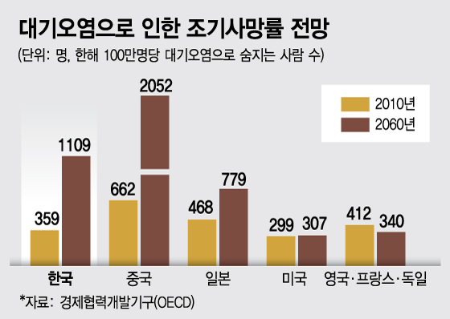

[figure not shown]

## 데이터 관련 전문지식

데이터의 경우 각종 전문용어들이 많을 뿐더러 위의 현상을 파악하기 위한 다양하 변수들이 필요하므로 논문과 통계자료들을 살펴볼 필요가 있다. 건강부문의 경우, ’국민건강보험공단’의 사이트를 참조하는 것이 도움될 것 이다.